# de momo a la sobredispersión

2020-09-18 carlos j. gil bellosta [@gilbellosta](https://twitter.com/gilbellosta) datanalytics.com · circiter.es

# motivación

## momo

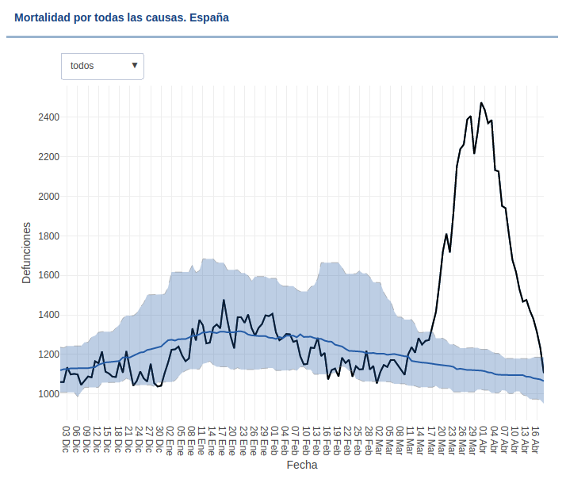

## momocalor

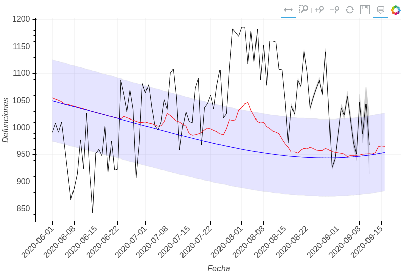

## otros veranos

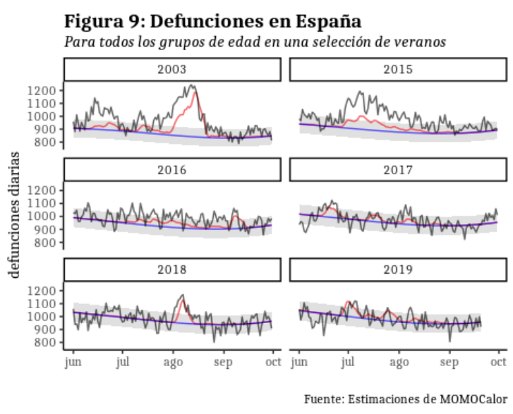

# la distribución de poisson

## bernoulli

[figure not shown]

## binomial

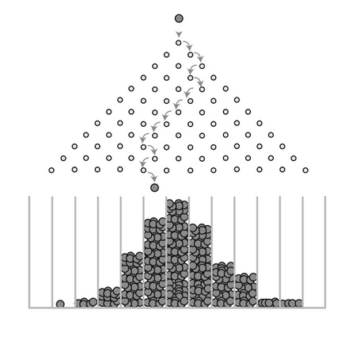

## ¿micromuertes?

- evento: don x está sano y vivo a las 8:00; a las 23:59 está en el tanatorio
- probabilidad: ~ 1 entre un millón (en países occidentales)

## poisson

- es una aproximación a la binomial cuando $N$ es grande
- $N \times p$ es la tasa $\lambda$
- lo anterior es una caracterización útil de la poisson
- sobre todo, nos indica dónde y cómo se puede usar

## dualidad binomial-poisson y micromuertes

- física: dualidad onda-partícula
- estadística / conteos: dualidad binomial-poisson
- por tanto, se puede decir que en españa se dan ~50 eventos como los de don x al día

# el modelo de poisson

## hagamos física

$$N \sim \text{Pois}(\lambda)$$

y el problema consiste en estimar $\lambda$ a partir de datos (pista: la media es el emv)

## fuera de la física…

- los sujetos son heterogéneos
- cada $N_i$ tiene su propia $\lambda_i$
- ¿?

## glm

- cada $N_i$ tiene variables $x_{i1}, \dots x_{in}$
- `glm`: prácticamente la solución más sencilla
- el $\lambda_i$ de cada $N_i$ se estima como
  - función lineal de las $x_{i1}, \dots x_{in}$
  - y se le hace $\exp$ para garantizar $\lambda_i > 0$

$$N_i \sim \text{Pois}\left(\exp\left(a_0 + \sum_j a_j x_{ij}\right)\right)$$

# sobredispersión

## digresión: infradispersión

[figure not shown]

## infradispersión en rusia

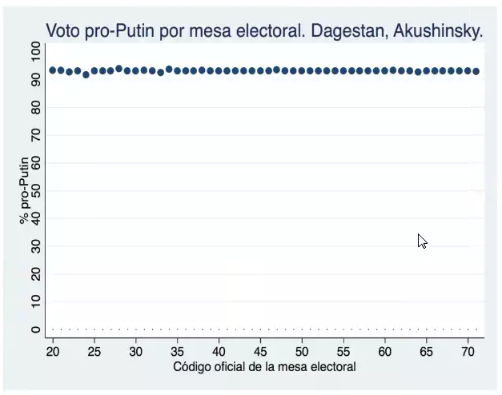

## sobredispersión

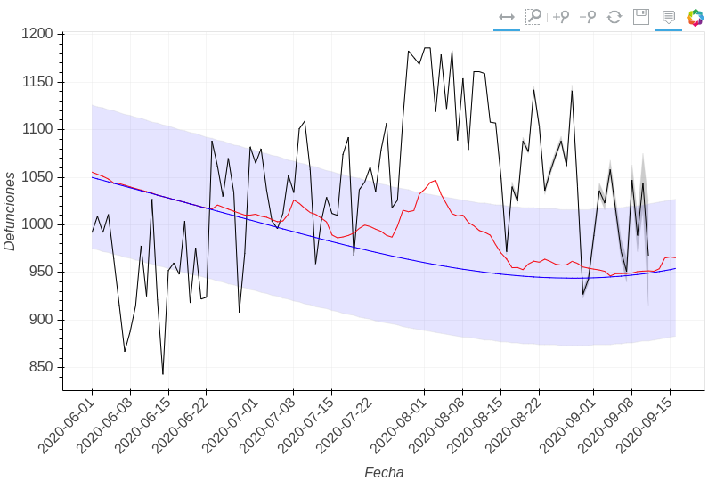

## en momocalor

- cada $N_i$ (o día) tiene una distribución diferente
- las variables $x_{i1}, \dots x_{in}$ usadas no recogen toda la información necesaria para caracterizarlos
- recordad, en `lm`: $y_i = a_0 + \sum_j a_j x_{ij} + \epsilon_i$
- sin embargo, en `glm`

$$N_i \sim \text{Pois}\left(\exp\left(a_0 + \sum_j a_j x_{ij}\right)\right)$$

# una formulación alternativa

## una formulación alternativa

$$\log(\lambda_i) \sim N\left(a_0 + \sum_j a_j x_{ij}, \,\sigma \right)$$

(o bien, $\log(\lambda_i) \sim a_0 + \sum_j a_j x_{ij} + \epsilon_i$)

$$N_i \sim \text{Pois}(\lambda_i)$$

Es decir, un modelo con dos fuentes de aleatoriedad: en la estimación de $\lambda$ y en la predicción.

## implementación

- por supuesto, no en `glm`
- se puede plantear en `lme4`, `stan`, casi seguro en INLA,…
- se pueden consultar algunos ejemplos en mi blog

# nota final

## nota final

# vale.

## ... aunque la conversación continúa en:

## [http://circiter.es](http://www.circiter.es) · [@gilbellosta](https://twitter.com/gilbellosta) · http://datanalytics.com